# Data cleaning using Python:

## 1. What is data cleaning:

1)Data cleaning is the process of detecting and correcting or removing corrupt or inaccurate records from a record set which can be a table or database. 2)It refers to identifying incomplete, incorrect, inaccurate or irrelevant parts of the data and then replacing, modifying, or deleting the dirty data. 3)After cleansing, a data set should be consistent with other similar data sets in the system. 4)The inconsistencies detected or removed may have been originally caused by user entry errors, by corruption in transmission or storage, or by different data dictionary definitions of similar entities.

## 2. Why is Data Cleaning Important?

Data cleaning step determines how easy your modelling is going to be. The better your data is, the less complex your learning algorithms need to be. Better structured data that provides the right input values will also determine the accuracy of your predictions. Data cleaning impacts efficiency of rest of your data modeling and decision-making process. This step is critical algorithm building step. Efficiency gains of data cleaning results from: 1) Lesser processing time 2) More accurate predictions 3) Simpler algorithms needed 4) Better learning ability of the model

```python
import numpy as np
import pandas as pd

import matplotlib.pyplot as plt
import seaborn as sns
import plotly.offline as py
import plotly.graph_objs as go
import plotly.express as px
py.init_notebook_mode(connected=True)

import seaborn as sns

from bokeh.io import output_notebook, output_file, show, push_notebook
from bokeh.plotting import figure
from bokeh.models import ColumnDataSource, CategoricalColorMapper, HoverTool
from bokeh.models.widgets import Tabs, Panel
output_notebook()

from IPython.html.widgets import interact

from bubbly.bubbly import bubbleplot
get_ipython().run_line_magic('matplotlib', 'inline')
```

After importing all the required libraries we then upload the dataset by reading Data from CSV file.

```python
df = pd.read_csv('C:\\Users\\rohan\\appstore_games.csv', parse_dates=['Original Release Date', 'Current Version Release Date'])
df.head()
```

|  | URL | ID | Name | Subtitle | Icon URL | Average User Rating | User Rating Count | Price | In-app Purchases | Description | Developer | Age Rating | Languages | Size | Primary Genre | Genres | Original Release Date | Current Version Release Date |
| --- | --- | --- | --- | --- | --- | --- | --- | --- | --- | --- | --- | --- | --- | --- | --- | --- | --- | --- |
| 0 | https://apps.apple.com/us/app/sudoku/id284921427 | 284921427 | Sudoku | NaN | https://is2-ssl.mzstatic.com/image/thumb/Purpl... | 4.0 | 3553.0 | 2.99 | NaN | Join over 21,000,000 of our fans and download ... | Mighty Mighty Good Games | 4+ | DA, NL, EN, FI, FR, DE, IT, JA, KO, NB, PL, PT... | 15853568.0 | Games | Games, Strategy, Puzzle | 2008-11-07 | 2017-05-30 |
| 1 | https://apps.apple.com/us/app/reversi/id284926400 | 284926400 | Reversi | NaN | https://is4-ssl.mzstatic.com/image/thumb/Purpl... | 3.5 | 284.0 | 1.99 | NaN | The classic game of Reversi, also known as Oth... | Kiss The Machine | 4+ | EN | 12328960.0 | Games | Games, Strategy, Board | 2008-11-07 | 2018-05-17 |
| 2 | https://apps.apple.com/us/app/morocco/id284946595 | 284946595 | Morocco | NaN | https://is5-ssl.mzstatic.com/image/thumb/Purpl... | 3.0 | 8376.0 | 0.00 | NaN | Play the classic strategy game Othello (also k... | Bayou Games | 4+ | EN | 674816.0 | Games | Games, Board, Strategy | 2008-11-07 | 2017-05-09 |
| 3 | https://apps.apple.com/us/app/sudoku-free/id28... | 285755462 | Sudoku (Free) | NaN | https://is3-ssl.mzstatic.com/image/thumb/Purpl... | 3.5 | 190394.0 | 0.00 | NaN | Top 100 free app for over a year.\nRated "Best... | Mighty Mighty Good Games | 4+ | DA, NL, EN, FI, FR, DE, IT, JA, KO, NB, PL, PT... | 21552128.0 | Games | Games, Strategy, Puzzle | 2008-07-23 | 2017-05-30 |
| 4 | https://apps.apple.com/us/app/senet-deluxe/id2... | 285831220 | Senet Deluxe | NaN | https://is1-ssl.mzstatic.com/image/thumb/Purpl... | 3.5 | 28.0 | 2.99 | NaN | "Senet Deluxe - The Ancient Game of Life and A... | RoGame Software | 4+ | DA, NL, EN, FR, DE, EL, IT, JA, KO, NO, PT, RU... | 34689024.0 | Games | Games, Strategy, Board, Education | 2008-07-18 | 2018-07-22 |

Here we mentioned the number of rows and columns in the dataset by using the shape method.

```python
print(f"There are {df.shape[0]} rows and {df.shape[1]} columns in dataset")
```

```
There are 17007 rows and 18 columns in dataset
```

```python
df.info()
```

```
<class 'pandas.core.frame.DataFrame'>
RangeIndex: 17007 entries, 0 to 17006
Data columns (total 18 columns):
URL                             17007 non-null object
ID                              17007 non-null int64
Name                            17007 non-null object
Subtitle                        5261 non-null object
Icon URL                        17007 non-null object
Average User Rating             7561 non-null float64
User Rating Count               7561 non-null float64
Price                           16983 non-null float64
In-app Purchases                7683 non-null object
Description                     17007 non-null object
Developer                       17007 non-null object
Age Rating                      17007 non-null object
Languages                       16947 non-null object
Size                            17006 non-null float64
Primary Genre                   17007 non-null object
Genres                          17007 non-null object
Original Release Date           17007 non-null datetime64[ns]
Current Version Release Date    17007 non-null datetime64[ns]
dtypes: datetime64[ns](2), float64(4), int64(1), object(11)
memory usage: 2.3+ MB
```

Mostly Subtitle and Averge User Ratings and In-app purchases have most null values

```python
df.describe()
```

|  | ID | Average User Rating | User Rating Count | Price | Size |
| --- | --- | --- | --- | --- | --- |
| count | 1.700700e+04 | 7561.000000 | 7.561000e+03 | 16983.000000 | 1.700600e+04 |
| mean | 1.059614e+09 | 4.060905 | 3.306531e+03 | 0.813419 | 1.157064e+08 |
| std | 2.999676e+08 | 0.751428 | 4.232256e+04 | 7.835732 | 2.036477e+08 |
| min | 2.849214e+08 | 1.000000 | 5.000000e+00 | 0.000000 | 5.132800e+04 |
| 25% | 8.996543e+08 | 3.500000 | 1.200000e+01 | 0.000000 | 2.295014e+07 |
| 50% | 1.112286e+09 | 4.500000 | 4.600000e+01 | 0.000000 | 5.676895e+07 |
| 75% | 1.286983e+09 | 4.500000 | 3.090000e+02 | 0.000000 | 1.330271e+08 |
| max | 1.475077e+09 | 5.000000 | 3.032734e+06 | 179.990000 | 4.005591e+09 |

Here we can see mean, min, max values for Average User Rating and User Rating Count, Price, Size

Extracting the apps having at least 200 reviews and selecting our primary genre as games.

```python
df = df.loc[(df['User Rating Count'] > 200) & (df['Primary Genre']=='Games')]
```

# Different Types of Categories

```python
# '''A Function To Plot Pie Plot using Plotly'''

def pie_plot(cnt_srs, colors, title):
    labels=cnt_srs.index
    values=cnt_srs.values
    trace = go.Pie(labels=labels,
                   values=values,
                   title=title,
                   hoverinfo='percent+value',
                   textinfo='percent',
                   textposition='inside',
                   hole=0.7,
                   showlegend=True,
                   marker=dict(colors=colors,
                               line=dict(color='#000000',
                                         width=2),
                              )
                  )
    return trace
```

```python
py.iplot([pie_plot(df['Genres'].value_counts().sort_values(ascending=False).head(10), ['cyan'], 'Genres')]
```

[interactive chart not shown]

What we can figure out is that Games are mostly based on strategy, simulation and action genres in App Store.

# Evolution of Games Over the Time

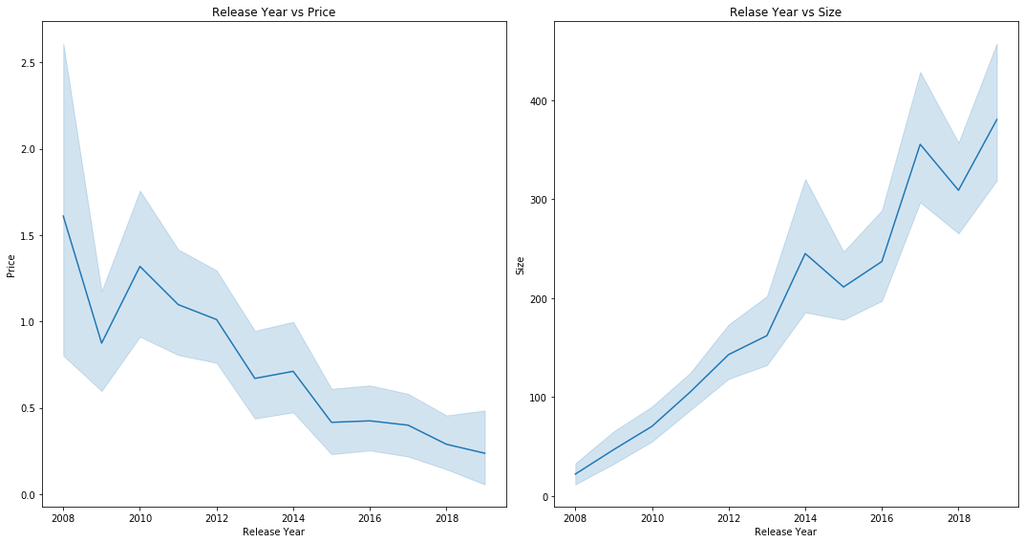

```python
df['Release Year'] = df['Original Release Date'].dt.year

fig, ax = plt.subplots(1, 2, figsize=(15, 8))
sns.lineplot(x='Release Year', y='Price', data=df, palette='Wistia', ax=ax[0])
ax[0].set_title('Release Year vs Price')

sns.lineplot(x='Release Year', y='Size', data=df, palette='Wistia', ax=ax[1])
ax[1].set_title('Relase Year vs Size')
plt.tight_layout()
plt.show()
```

We Can Observe that prices for the games decreased tremendously but Size of the game increased which is obvious as most of us have access internet and we can easily download a 1-2GB game.

```python
df.dropna(inplace=True)
data = df.set_index('Release Year')
y = data.loc[2008].Size
x = data.loc[2008].Price
data = data[['Name', 'Price', 'Size']]
output_notebook()
```

We can observe the price and size ratio for different years.

```python
source = ColumnDataSource(data={
    "x": data.loc[2009].Price,
    "y": data.loc[2009].Size,
    "Name": data.loc[2009].Name,
    "Price": data.loc[2009].Price,
    "Size": data.loc[2009].Size
})
hover = HoverTool(tooltips=[('Name', '@Name'), ('Price', '@Price'), ('Size', '@Size')])
plot = figure(title='Evolution Of Games', x_axis_label='Price', y_axis_label='Size', tools=[hover, 'crosshair', 'pan', 'box_zoom'])
plot.circle('x', 'y' , source=source, hover_color='red')

def update(x_axis, y_axis, year=2009):
    c1=x_axis
    c2=y_axis
    new_data={
        "x":data.loc[year, c1],
        "y":data.loc[year, c2],
        "Name":data.loc[year].Name,
        "Price": data.loc[year].Price,
        "Size": data.loc[year].Size
     }
    source.data = new_data
    plot.xaxis.axis_label=c1
    plot.yaxis.axis_label=c2
    push_notebook()

show(plot, notebook_handle=True)
```

[interactive chart not shown]

`<Bokeh Notebook handle for In[16]>`

```python
 #'''Toggle year from here It will show up when u will fork the kernel and run this cell'''
interact(update, x_axis=['Price'], y_axis=['Size'], year=(2009, 2019))
```

```
<function __main__.update(x_axis, y_axis, year=2009)>
```

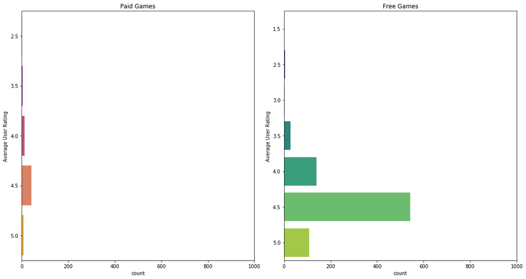

```python
paid = df[df['Price']>0]
free = df[df['Price']==0]
fig, ax = plt.subplots(1, 2, figsize=(15,8))
sns.countplot(data=paid, y='Average User Rating', ax=ax[0], palette='plasma')
ax[0].set_title('Paid Games')
ax[0].set_xlim([0, 1000])

sns.countplot(data=free, y='Average User Rating', ax=ax[1], palette='viridis')
ax[1].set_title('Free Games')
ax[1].set_xlim([0,1000])
plt.tight_layout();
plt.show()
```

```
1.As expected there are less number of paid games than free games
2.But Still we cannot see any difference in user ratings of both the categories
3.Most of the Games are rated quite good around 4.0-5.0
4.It doesn't seem like price has an impact on the ratings as both free and paid games have almost same ratings
```

# Age Rating

```python
py.iplot([pie_plot(df['Age Rating'].value_counts(), ['cyan', 'gold', 'red'], 'Age Rating')])
```

[interactive chart not shown]

# Most Expensive Game:

```python
price = df.sort_values(by='Price', ascending=False)[['Name', 'Price', 'Average User Rating', 'Size', 'Icon URL']].head(10)
price.iloc[:, 0:-1]
```

|  | Name | Price | Average User Rating | Size |
| --- | --- | --- | --- | --- |
| 673 | Ticket to Ride | 6.99 | 4.0 | 669.0 |
| 12016 | Kingdom Rush Vengeance | 4.99 | 5.0 | 751.0 |
| 2816 | Hitman GO | 4.99 | 4.5 | 1106.0 |
| 8668 | Bloons TD 6 | 4.99 | 5.0 | 164.0 |
| 10872 | 911 Operator | 4.99 | 4.5 | 229.0 |
| 1275 | Le Havre (The Harbor) | 4.99 | 4.5 | 203.0 |
| 644 | Forbidden Island | 4.99 | 4.5 | 141.0 |
| 1386 | 7 Wonders | 4.99 | 4.0 | 522.0 |
| 1399 | Warlords Classic Strategy | 4.99 | 4.5 | 24.0 |
| 9992 | Eight-Minute Empire | 4.99 | 4.5 | 267.0 |

[figure not shown]

```python
import urllib.request
from PIL import Image

plt.figure(figsize=(6,3))
plt.subplot(121)
image = Image.open(urllib.request.urlopen(price.iloc[0,-1]))
plt.imshow(image)
plt.axis('off')

plt.subplot(122)
image = Image.open(urllib.request.urlopen(price.iloc[1,-1]))
plt.imshow(image)
plt.axis('off')

plt.show()
```

# Most Reviewed Game

```python
review = df.sort_values(by='User Rating Count', ascending=False)[['Name', 'Price', 'Average User Rating', 'Size', 'User Rating Count', 'Icon URL']].head(10)
review.iloc[:, 0:-1]
```

|  | Name | Price | Average User Rating | Size | User Rating Count |
| --- | --- | --- | --- | --- | --- |
| 1378 | Clash of Clans | 0.0 | 4.5 | 161.0 | 3032734.0 |
| 7187 | Clash Royale | 0.0 | 4.5 | 145.0 | 1277095.0 |
| 13414 | PUBG MOBILE | 0.0 | 4.5 | 2384.0 | 711409.0 |
| 1921 | Plants vs. Zombies\u2122 2 | 0.0 | 4.5 | 121.0 | 469562.0 |
| 8139 | Pok\xe9mon GO | 0.0 | 3.5 | 282.0 | 439776.0 |
| 2410 | Boom Beach | 0.0 | 4.5 | 203.0 | 400787.0 |
| 12473 | Cash, Inc. Fame & Fortune Game | 0.0 | 5.0 | 246.0 | 374772.0 |
| 8632 | Idle Miner Tycoon: Cash Empire | 0.0 | 4.5 | 444.0 | 283035.0 |
| 3550 | Star Wars\u2122: Commander | 0.0 | 4.5 | 123.0 | 259030.0 |
| 6144 | Agar.io | 0.0 | 4.5 | 84.0 | 257852.0 |

```
1.Clash Of Clans
2.Clash Royale
3.PUBG Mobile
Are the Most Reviewed Games and We can also say Popular Games on App Store
```

[figure not shown]

```python
plt.figure(figsize=(6,3))
plt.subplot(131)
image = Image.open(urllib.request.urlopen(review.iloc[0,-1]))
plt.imshow(image)
plt.axis('off')

plt.subplot(132)
image = Image.open(urllib.request.urlopen(review.iloc[1,-1]))
plt.imshow(image)
plt.axis('off')

plt.subplot(133)
image = Image.open(urllib.request.urlopen(review.iloc[2,-1]))
plt.imshow(image)
plt.axis('off')

plt.show()
```

A tag cloud (word cloud, or weighted list in visual design) is a novelty visual representation of text data, typically used to depict keyword metadata (tags) on websites, or to visualize free form text. Using WordCloud package, we can easily make workcloud image.

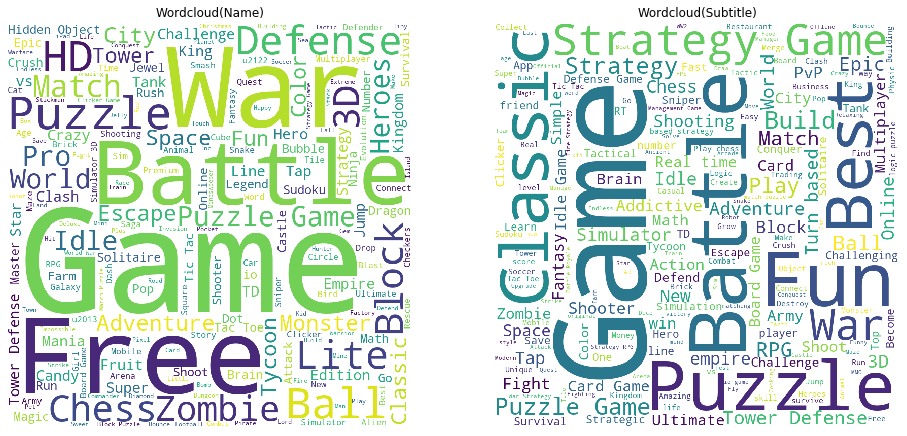

```python
from wordcloud import WordCloud # wordcloud
import missingno as msno # check missing value

fig, ax = plt.subplots(1, 2, figsize=(16,32))
wordcloud = WordCloud(background_color='white',width=800, height=800).generate(' '.join(data['Name']))
wordcloud_sub = WordCloud(background_color='white',width=800, height=800).generate(' '.join(data['Subtitle'].dropna().astype(str)) )
ax[0].imshow(wordcloud)
ax[0].axis('off')
ax[0].set_title('Wordcloud(Name)')
ax[1].imshow(wordcloud_sub)
ax[1].axis('off')
ax[1].set_title('Wordcloud(Subtitle)')
plt.show()
```

# Best Overall Game

```python
best = df.sort_values(by=['Average User Rating', 'User Rating Count'], ascending=False)[['Name', 'Average User Rating', 'User Rating Count', 'Size',
                                                                                         'Price', 'Icon URL']].head(10)
best.iloc[:, 0:-1]
```

|  | Name | Average User Rating | User Rating Count | Size | Price |
| --- | --- | --- | --- | --- | --- |
| 12473 | Cash, Inc. Fame & Fortune Game | 5.0 | 374772.0 | 246.0 | 0.00 |
| 6089 | Egg, Inc. | 5.0 | 174591.0 | 75.0 | 0.00 |
| 14155 | AFK Arena | 5.0 | 156766.0 | 226.0 | 0.00 |
| 8388 | South Park: Phone Destroyer\u2122 | 5.0 | 156044.0 | 130.0 | 0.00 |
| 13261 | From Zero to Hero: Cityman | 5.0 | 146729.0 | 297.0 | 0.00 |
| 15266 | Sushi Bar Idle | 5.0 | 123606.0 | 257.0 | 0.00 |
| 10418 | Fire Emblem Heroes | 5.0 | 120283.0 | 176.0 | 0.00 |
| 1649 | Bloons TD 5 | 5.0 | 97776.0 | 133.0 | 2.99 |
| 16434 | Idle Roller Coaster | 5.0 | 88855.0 | 234.0 | 0.00 |
| 11722 | Mafia City: War of Underworld | 5.0 | 88542.0 | 181.0 | 0.00 |

```
1.Cash, Inc. Fame & Fortune Game turns out to be best overall game with 5.0 rating and 374772 reviews
2.There are also a lot of other Games with 5.0 rating and healthy number of reviews
```

[figure not shown]

```python
plt.figure(figsize=(5,5))
image = Image.open(urllib.request.urlopen(best.iloc[0, -1]))
plt.axis('off')
plt.imshow(image)
plt.show()
```

## Below plots shows top 100 games

[figure not shown]

```python
import matplotlib.pyplot as plt
import requests
from PIL import Image
from io import BytesIO

fig, ax = plt.subplots(10,10, figsize=(12,12))

for i in range(100):
    r = requests.get(data['Icon_URL'][i])
    im = Image.open(BytesIO(r.content))
    ax[i//10][i%10].imshow(im)
    ax[i//10][i%10].axis('off')
plt.show()
```

# Regression Analysis

## Correlation:

Correlation is usually defined as a measure of the linear relationship between two quantitative variables (e.g., height and weight). Often a slightly looser definition is used, whereby correlation simply means that there is some type of relationship between two variables. This post will define positive and negative correlation, provide some examples of correlation, explain how to measure correlation and discuss some pitfalls regarding correlation.

[figure not shown]

```python
import pandas as pd
import matplotlib.pyplot as plt
df.plot(kind='scatter',x='Average User Rating',y='Price') # scatter plot
```

```python
df.corr(method ='pearson')
```

|  | ID | Average User Rating | User Rating Count | Price | Size | Release Year |
| --- | --- | --- | --- | --- | --- | --- |
| ID | 1.000000 | 0.232108 | -0.071437 | -0.241213 | 0.171966 | 0.957707 |
| Average User Rating | 0.232108 | 1.000000 | 0.043101 | -0.016481 | -0.021701 | 0.248763 |
| User Rating Count | -0.071437 | 0.043101 | 1.000000 | -0.021132 | 0.025048 | -0.066089 |
| Price | -0.241213 | -0.016481 | -0.021132 | 1.000000 | 0.059496 | -0.229102 |
| Size | 0.171966 | -0.021701 | 0.025048 | 0.059496 | 1.000000 | 0.210473 |
| Release Year | 0.957707 | 0.248763 | -0.066089 | -0.229102 | 0.210473 | 1.000000 |

```python
data = [
    go.Heatmap(
        z = df.corr().values,
        x = df.corr().columns.values,
        y = df.corr().columns.values,
        colorscale='YlGnBu',
        reversescale=False,
    )
]

layout = go.Layout(
    title='Pearson Correlation of float-type features',
    xaxis = dict(ticks=''),
    yaxis = dict(ticks='' ),
    width = 400, height = 400,
    margin = dict(
        l = 100
    )
)

fig = go.Figure(data=data, layout=layout)
py.iplot(fig, filename='labelled-heatmap')
```

[interactive chart not shown]

Above is Pearson correlation in matrix format.

```python
data=pd.read_csv('C:\\Users\\rohan\\appstore_games1.csv')
data.head()
```

|  | URL | ID | Name | Subtitle | Icon_URL | Average_User_Rating | User_Rating_Count | Price | In_app_Purchases | Description | Developer | Age_Rating | Languages | Size | Primary_Genre | Genres | Original_Release_Date | Current_Version_Release_Date |
| --- | --- | --- | --- | --- | --- | --- | --- | --- | --- | --- | --- | --- | --- | --- | --- | --- | --- | --- |
| 0 | https://apps.apple.com/us/app/sudoku/id284921427 | 284921427 | Sudoku | NaN | https://is2-ssl.mzstatic.com/image/thumb/Purpl... | 4.0 | 3553.0 | 2.99 | NaN | Join over 21,000,000 of our fans and download ... | Mighty Mighty Good Games | 4+ | DA, NL, EN, FI, FR, DE, IT, JA, KO, NB, PL, PT... | 15853568.0 | Games | Games, Strategy, Puzzle | 11/7/2008 | 30/05/2017 |
| 1 | https://apps.apple.com/us/app/reversi/id284926400 | 284926400 | Reversi | NaN | https://is4-ssl.mzstatic.com/image/thumb/Purpl... | 3.5 | 284.0 | 1.99 | NaN | The classic game of Reversi, also known as Oth... | Kiss The Machine | 4+ | EN | 12328960.0 | Games | Games, Strategy, Board | 11/7/2008 | 17/05/2018 |
| 2 | https://apps.apple.com/us/app/morocco/id284946595 | 284946595 | Morocco | NaN | https://is5-ssl.mzstatic.com/image/thumb/Purpl... | 3.0 | 8376.0 | 0.00 | NaN | Play the classic strategy game Othello (also k... | Bayou Games | 4+ | EN | 674816.0 | Games | Games, Board, Strategy | 11/7/2008 | 5/9/2017 |
| 3 | https://apps.apple.com/us/app/sudoku-free/id28... | 285755462 | Sudoku (Free) | NaN | https://is3-ssl.mzstatic.com/image/thumb/Purpl... | 3.5 | 190394.0 | 0.00 | NaN | Top 100 free app for over a year.\nRated "Best... | Mighty Mighty Good Games | 4+ | DA, NL, EN, FI, FR, DE, IT, JA, KO, NB, PL, PT... | 21552128.0 | Games | Games, Strategy, Puzzle | 23/07/2008 | 30/05/2017 |
| 4 | https://apps.apple.com/us/app/senet-deluxe/id2... | 285831220 | Senet Deluxe | NaN | https://is1-ssl.mzstatic.com/image/thumb/Purpl... | 3.5 | 28.0 | 2.99 | NaN | "Senet Deluxe - The Ancient Game of Life and A... | RoGame Software | 4+ | DA, NL, EN, FR, DE, EL, IT, JA, KO, NO, PT, RU... | 34689024.0 | Games | Games, Strategy, Board, Education | 18/07/2008 | 22/07/2018 |

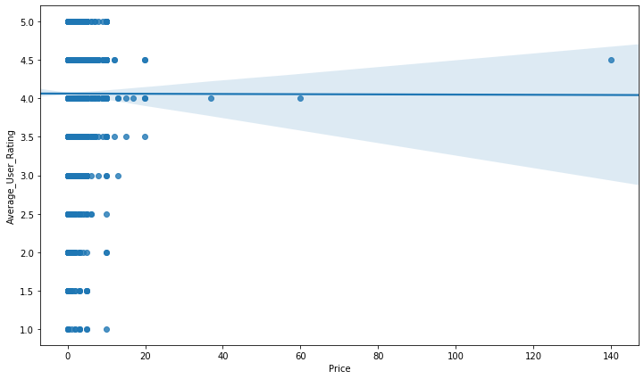

```python
fig, ax = plt.subplots(1,1, figsize=(12, 7), dpi=72)
sns.regplot(data=data, x='Price', y='Average_User_Rating', ax=ax)
plt.show()
```

# Mean and Standard Deviation

The mean is a measure of central tendency. The standard deviation is a measure of dispersion. Both are appropriate descriptive statistics for normally distributed data sets using ratio or interval scaling. Both mean and standard deviation are used in calculating some correlation coefficients, effect sizes, t scores, F scores (Analysis of Variance).

We define an relationship between price and rating in below table based on Mean and Standard Deviation.

```python
price_list = sorted(data['Price'].dropna().unique())
rating_stat = pd.DataFrame(columns=['mean', 'std', 'count'], index=price_list)
for price in price_list:
    tmp = data[data['Price']==price]['Average_User_Rating'].dropna()
    rating_stat['mean'][price] = tmp.mean()
    rating_stat['std'][price] = tmp.std()
    rating_stat['count'][price] = len(tmp)

rating_stat.T.head(len(price_list))
```

|  | 0.00 | 0.99 | 1.99 | 2.99 | 3.99 | 4.99 | 5.99 | 6.99 | 7.99 | 8.99 | ... | 16.99 | 18.99 | 19.99 | 29.99 | 36.99 | 37.99 | 59.99 | 99.99 | 139.99 | 179.99 |
| --- | --- | --- | --- | --- | --- | --- | --- | --- | --- | --- | --- | --- | --- | --- | --- | --- | --- | --- | --- | --- | --- |
| mean | 4.07123 | 3.90341 | 4.02239 | 4 | 4.1619 | 4.06216 | 4 | 4.17308 | 4.15 | 4.16667 | ... | 4 | NaN | 4.1 | NaN | 4 | NaN | 4 | NaN | 4.5 | NaN |
| std | 0.745921 | 0.79746 | 0.814399 | 0.827804 | 0.60246 | 0.780312 | 0.666667 | 0.488719 | 0.579751 | 0.389249 | ... | NaN | NaN | 0.41833 | NaN | NaN | NaN | NaN | NaN | NaN | NaN |
| count | 6325 | 352 | 201 | 252 | 105 | 185 | 28 | 26 | 10 | 12 | ... | 1 | 0 | 5 | 0 | 1 | 0 | 1 | 0 | 1 | 0 |

3 rows × 24 columns

# R-Squared

R-squared (R2) is a statistical measure that represents the proportion of the variance for a dependent variable that's explained by an independent variable or variables in a regression model.

```python
lm.rsquared
```

```
0.00012430648001193756
```

```python
data['GenreList'] = data['Genres'].apply(lambda s : s.replace('Games','').replace('&',' ').replace(',', ' ').split())
data['GenreList'].head()
```

```
0              [Strategy, Puzzle]
1               [Strategy, Board]
2               [Board, Strategy]
3              [Strategy, Puzzle]
4    [Strategy, Board, Education]
Name: GenreList, dtype: object
```

```python
from sklearn.preprocessing import MultiLabelBinarizer # Similar to One-Hot Encoding

test = data['GenreList']
mlb = MultiLabelBinarizer()
res = pd.DataFrame(mlb.fit_transform(test), columns=mlb.classes_, index=test.index)
```

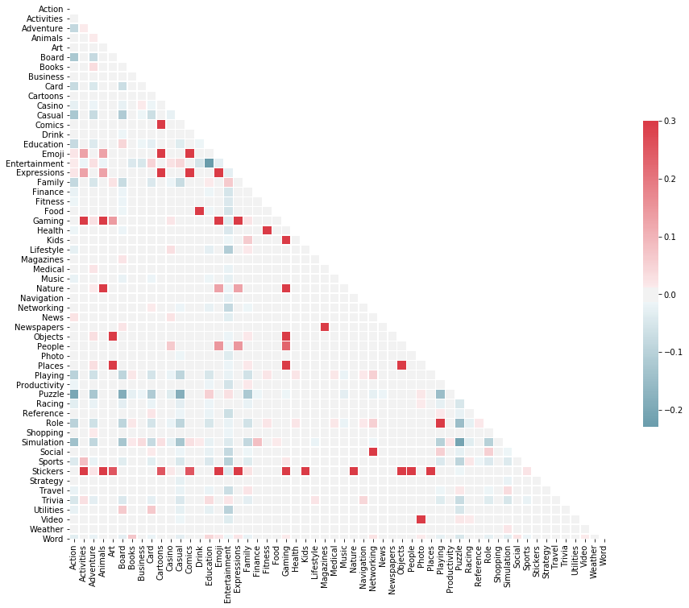

```python
corr = res.corr()
mask = np.zeros_like(corr, dtype=np.bool)
mask[np.triu_indices_from(mask)] = True
f, ax = plt.subplots(figsize=(15, 14))
cmap = sns.diverging_palette(220, 10, as_cmap=True)
sns.heatmap(corr, mask=mask, cmap=cmap, vmax=.3, center=0,square=True, linewidths=.5, cbar_kws={"shrink": .5})
```

[figure not shown]

```python
sns.distplot(y, hist=True, kde=False, bins=9, hist_kws={'edgecolor':'#000000'})
```

Citations:

```
https://www.kaggle.com/subinium/road-to-viz-expert-1-unusual-tools
https://www.kaggle.com/hkhoi91/data-viz-what-to-focus-on-as-a-game-dev
https://www.kaggle.com/spidyweb/gaming-industry-visualization
https://www.kaggle.com/thedatadude/eda-app-to-ratings
https://www.kaggle.com/margesh/regression-scikit-xgb-h2o-automl
```